# River Crossing Puzzles

Mark Borg

08 August 2018

This R notebook is about **River Crossing Puzzles**.

For a description of these puzzles and how we go about creating the solution presented here, please see [this related blog entry](https://mark-borg.github.io/blog/2016/river-crossing-puzzles/).

```r
source('solve_river_crossing_puzzles.R')
```

**Farmer-Wolf-Goat-Cabbage puzzle**

Setting up the incompatibilities between the different entities as a directed graph. E.g. Wolf (W) eats Goat (G). And creating the search space illustrating all possible transitions (moves) that can be done.

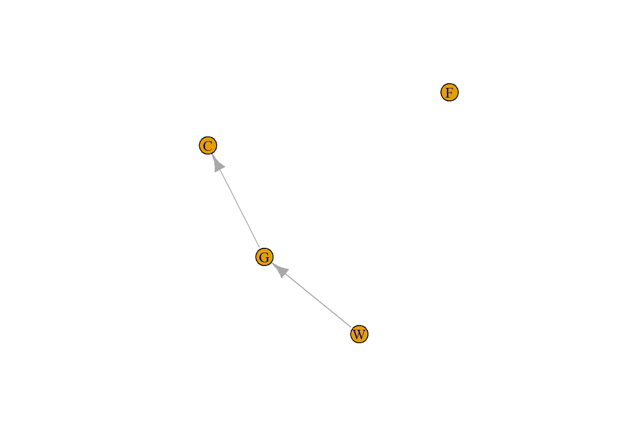

```r
require(igraph)

# the graph showing object incompatibilities
gr <- make_empty_graph(directed = TRUE)
gr <- add.vertices(gr, 4, name = c('F', 'W', 'G', 'C'))
gr <- add.edges(gr, c('W','G', 'G','C'))
plot(gr)
```

```r
# create the search space
gss <- make_empty_graph(directed=TRUE)

boat.capacity <-2
farmer.symbol <- 'F'

# create the initial state
state0 <- list(bank.l = c('F', 'W', 'G', 'C'), bank.r = c(), boat.pos = 1)
state0 <- make.state.name(state0)

# add the initial state as a node in the search space
gss <- add.vertices(gss, 1, name=state0$name)
V(gss)[1]$color <- 'red'

gss <- solve(gss, state0)
```

```
## solving CFGWb|
##   transition F W
##   transition F G
## CW|FGb is valid
## solving CW|FGb
##   transition F G
## CFGWb| is valid
##   transition F NA
## CFWb|G is valid
## solving CFWb|G
##   transition W F
## C|FGWb is valid
## solving C|FGWb
##   transition G F
## CFGb|W is valid
## solving CFGb|W
##   transition C F
## G|CFWb is valid
## solving G|CFWb
##   transition W F
## FGWb|C is valid
## solving FGWb|C
##   transition G F
## W|CFGb is valid
## solving W|CFGb
##   transition C F
## CFWb|G is valid
##   transition G F
## FGWb|C is valid
##   transition F NA
##   transition NA F
##   transition W F
## G|CFWb is valid
##   transition F NA
##   transition C F
## CFGb|W is valid
##   transition F NA
## FGb|CW is valid
## solving FGb|CW
##   transition G F
```

[output cut: 9 more lines]

```
##   transition F NA
## G|CFWb is valid
##   transition NA F
##   transition G F
## C|FGWb is valid
##   transition F NA
##   transition W F
## CFWb|G is valid
##   transition F NA
##   transition C F
## W|CFGb is valid
##   transition F NA
## CW|FGb is valid
##   transition F C
##   transition F NA
```

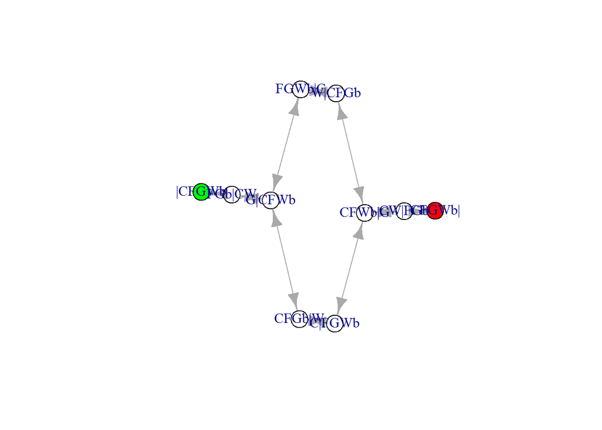

```r
gss <- simplify(gss, remove.loops = FALSE, remove.multiple = TRUE)

V(gss)[startsWith(V(gss)$name, '|')]$color <- 'green'
plot(gss)
```

Solving the puzzle by finding valid paths in the search space.

```r
paths <- get.all.shortest.paths(gss, 'CFGWb|', '|CFGWb')
print(paths)
```

```
## $res
## $res[[1]]
## + 8/10 vertices, named, from b2550fa:
## [1] CFGWb| CW|FGb CFWb|G W|CFGb FGWb|C G|CFWb FGb|CW |CFGWb
##
## $res[[2]]
## + 8/10 vertices, named, from b2550fa:
## [1] CFGWb| CW|FGb CFWb|G C|FGWb CFGb|W G|CFWb FGb|CW |CFGWb
##
##
## $nrgeo
##  [1] 1 1 1 1 1 2 1 1 2 2
```

```r
paths <- get.all.shortest.paths(gss, V(gss)[endsWith(V(gss)$name, '|')], V(gss)[startsWith(V(gss)$name, '|')])
print(paths)
```

```
## $res
## $res[[1]]
## + 8/10 vertices, named, from b2550fa:
## [1] CFGWb| CW|FGb CFWb|G W|CFGb FGWb|C G|CFWb FGb|CW |CFGWb
##
## $res[[2]]
## + 8/10 vertices, named, from b2550fa:
## [1] CFGWb| CW|FGb CFWb|G C|FGWb CFGb|W G|CFWb FGb|CW |CFGWb
##
##
## $nrgeo
##  [1] 1 1 1 1 1 2 1 1 2 2
```

**Farmer-Fox-Chicken-Spider-Caterpillar-Lettuce**

Setting up the incompatibilities between the different entities as a directed graph. E.g. Fox (F) eats Chicken (C). And creating the search space illustrating all possible transitions (moves) that can be done.

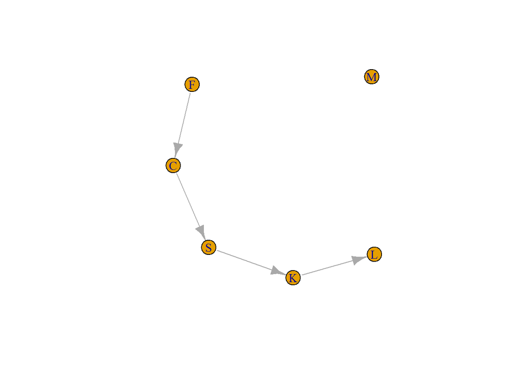

```r
# the graph showing object incompatibilities
gr <- make_empty_graph(directed = TRUE)
gr <- add.vertices(gr, 6, name = c('M', 'F', 'C', 'S', 'K', 'L'))
gr <- add.edges(gr, c('F','C', 'C','S', 'S', 'K', 'K', 'L'))
plot(gr)
```

```r
# create the search space
gss <- make_empty_graph(directed=FALSE)


boat.capacity <- 3
farmer.symbol <- 'M'

# create the initial state
state0 <- list(bank.l = c('M', 'F', 'C', 'S', 'K', 'L'), bank.r = c(), boat.pos = 1)
state0 <- make.state.name(state0)

# add the initial state as a node in the search space
gss <- add.vertices(gss, 1, name=state0$name)
V(gss)[1]$color <- 'red'

gss <- solve(gss, state0)
```

```
## solving CFKLMSb|
##   transition M F C
##   transition M F S
##   transition M F K
##   transition M F L
##   transition M F NA
##   transition M C S
##   transition M C K
## FLS|CKMb is valid
## solving FLS|CKMb
##   transition M C K
## CFKLMSb| is valid
##   transition M C NA
## CFLMSb|K is valid
## solving CFLMSb|K
##   transition F S M
## CL|FKMSb is valid
## solving CL|FKMSb
##   transition K F M
## CFKLMb|S is valid
## solving CFKLMb|S
##   transition L C M
## FK|CLMSb is valid
## solving FK|CLMSb
##   transition S L M
## FKLMSb|C is valid
## solving FKLMSb|C
##   transition K F M
## LS|CFKMb is valid
## solving LS|CFKMb
##   transition C K M
## CKLMSb|F is valid
## solving CKLMSb|F
##   transition S L M
## CK|FLMSb is valid
## solving CK|FLMSb
##   transition F S M
## CFKMSb|L is valid
## solving CFKMSb|L
##   transition C K M
```

[output cut: 393 more lines]

```
## FLS|CKMb is valid
##   transition M NA NA
##   transition M K NA
## FKLMSb|C is valid
##   transition M NA NA
## FLMSb|CK is valid
##   transition M C L
##   transition M C NA
##   transition M S K
##   transition M S L
##   transition M S NA
##   transition M K L
##   transition M K NA
##   transition M L NA
##   transition M NA NA
```

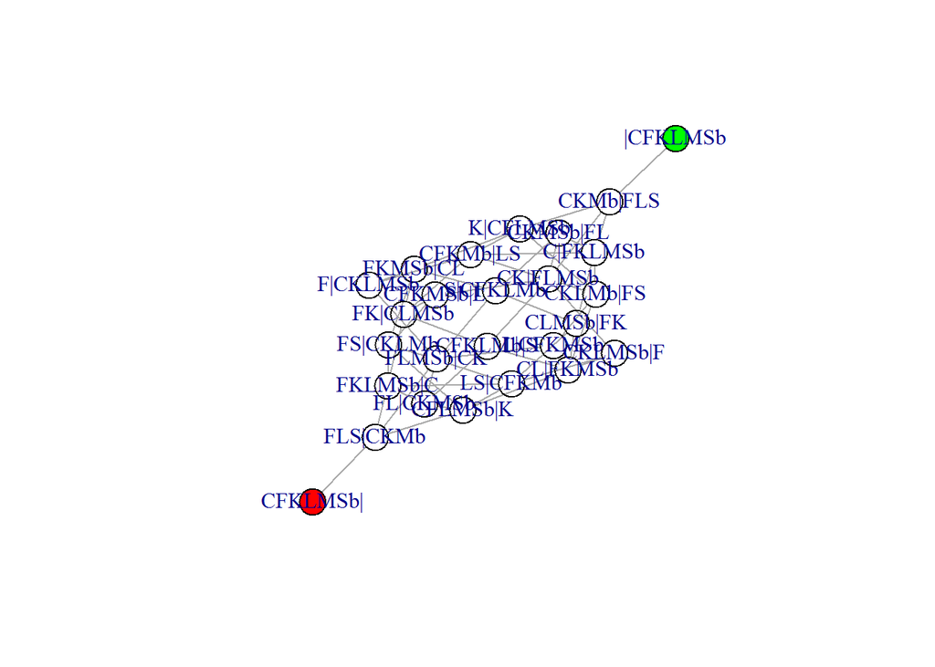

```r
gss <- simplify(gss, remove.loops = FALSE, remove.multiple = TRUE)

V(gss)[startsWith(V(gss)$name, '|')]$color <- 'green'
plot(gss)
```

Solving the puzzle by finding valid paths in the search space.

```r
paths <- get.all.shortest.paths(gss, 'CFKLMSb|', '|CFKLMSb')
print(paths)
```

```
## $res
## $res[[1]]
## + 8/26 vertices, named, from b36dfce:
## [1] CFKLMSb| FLS|CKMb FLMSb|CK S|CFKLMb CKMSb|FL CK|FLMSb CKMb|FLS |CFKLMSb
##
## $res[[2]]
## + 8/26 vertices, named, from b36dfce:
## [1] CFKLMSb| FLS|CKMb FKLMSb|C FK|CLMSb CFKMb|LS CK|FLMSb CKMb|FLS |CFKLMSb
##
## $res[[3]]
## + 8/26 vertices, named, from b36dfce:
## [1] CFKLMSb| FLS|CKMb FLMSb|CK F|CKLMSb CFKMb|LS CK|FLMSb CKMb|FLS |CFKLMSb
##
## $res[[4]]
## + 8/26 vertices, named, from b36dfce:
## [1] CFKLMSb| FLS|CKMb FLMSb|CK FS|CKLMb CFKMSb|L CK|FLMSb CKMb|FLS |CFKLMSb
##
## $res[[5]]
## + 8/26 vertices, named, from b36dfce:
## [1] CFKLMSb| FLS|CKMb FKLMSb|C FS|CKLMb CFKMSb|L CK|FLMSb CKMb|FLS |CFKLMSb
##
## $res[[6]]
## + 8/26 vertices, named, from b36dfce:
## [1] CFKLMSb| FLS|CKMb CFLMSb|K FS|CKLMb CFKMSb|L CK|FLMSb CKMb|FLS |CFKLMSb
##
## $res[[7]]
## + 8/26 vertices, named, from b36dfce:
## [1] CFKLMSb| FLS|CKMb FKLMSb|C FK|CLMSb CFKMSb|L CK|FLMSb CKMb|FLS |CFKLMSb
##
## $res[[8]]
## + 8/26 vertices, named, from b36dfce:
## [1] CFKLMSb| FLS|CKMb CFLMSb|K CL|FKMSb CKLMb|FS CK|FLMSb CKMb|FLS |CFKLMSb
##
## $res[[9]]
## + 8/26 vertices, named, from b36dfce:
## [1] CFKLMSb| FLS|CKMb FLMSb|CK L|CFKMSb CKLMb|FS CK|FLMSb CKMb|FLS |CFKLMSb
##
## $res[[10]]
## + 8/26 vertices, named, from b36dfce:
## [1] CFKLMSb| FLS|CKMb CFLMSb|K CL|FKMSb CKLMSb|F CK|FLMSb CKMb|FLS |CFKLMSb
```

[output cut: 110 more lines]

```
## + 8/26 vertices, named, from b36dfce:
## [1] CFKLMSb| FLS|CKMb FLMSb|CK S|CFKLMb CLMSb|FK C|FKLMSb CKMb|FLS |CFKLMSb
##
## $res[[39]]
## + 8/26 vertices, named, from b36dfce:
## [1] CFKLMSb| FLS|CKMb CFLMSb|K CL|FKMSb CKLMb|FS C|FKLMSb CKMb|FLS |CFKLMSb
##
## $res[[40]]
## + 8/26 vertices, named, from b36dfce:
## [1] CFKLMSb| FLS|CKMb FLMSb|CK L|CFKMSb CKLMb|FS C|FKLMSb CKMb|FLS |CFKLMSb
##
##
## $nrgeo
##  [1]  1  1  1  1  5  1  1  3  4 18  4  3  1  1  2 11  6  1  6 11  2  1  1
## [24] 40 40  3
```

```r
paths <- get.all.shortest.paths(gss, V(gss)[endsWith(V(gss)$name, '|')], V(gss)[startsWith(V(gss)$name, '|')])
print(paths)
```

```
## $res
## $res[[1]]
## + 8/26 vertices, named, from b36dfce:
## [1] CFKLMSb| FLS|CKMb FLMSb|CK S|CFKLMb CKMSb|FL CK|FLMSb CKMb|FLS |CFKLMSb
##
## $res[[2]]
## + 8/26 vertices, named, from b36dfce:
## [1] CFKLMSb| FLS|CKMb FKLMSb|C FK|CLMSb CFKMb|LS CK|FLMSb CKMb|FLS |CFKLMSb
##
## $res[[3]]
## + 8/26 vertices, named, from b36dfce:
## [1] CFKLMSb| FLS|CKMb FLMSb|CK F|CKLMSb CFKMb|LS CK|FLMSb CKMb|FLS |CFKLMSb
##
## $res[[4]]
## + 8/26 vertices, named, from b36dfce:
## [1] CFKLMSb| FLS|CKMb FLMSb|CK FS|CKLMb CFKMSb|L CK|FLMSb CKMb|FLS |CFKLMSb
##
## $res[[5]]
## + 8/26 vertices, named, from b36dfce:
## [1] CFKLMSb| FLS|CKMb FKLMSb|C FS|CKLMb CFKMSb|L CK|FLMSb CKMb|FLS |CFKLMSb
##
## $res[[6]]
## + 8/26 vertices, named, from b36dfce:
## [1] CFKLMSb| FLS|CKMb CFLMSb|K FS|CKLMb CFKMSb|L CK|FLMSb CKMb|FLS |CFKLMSb
##
## $res[[7]]
## + 8/26 vertices, named, from b36dfce:
## [1] CFKLMSb| FLS|CKMb FKLMSb|C FK|CLMSb CFKMSb|L CK|FLMSb CKMb|FLS |CFKLMSb
##
## $res[[8]]
## + 8/26 vertices, named, from b36dfce:
## [1] CFKLMSb| FLS|CKMb CFLMSb|K CL|FKMSb CKLMb|FS CK|FLMSb CKMb|FLS |CFKLMSb
##
## $res[[9]]
## + 8/26 vertices, named, from b36dfce:
## [1] CFKLMSb| FLS|CKMb FLMSb|CK L|CFKMSb CKLMb|FS CK|FLMSb CKMb|FLS |CFKLMSb
##
## $res[[10]]
## + 8/26 vertices, named, from b36dfce:
## [1] CFKLMSb| FLS|CKMb CFLMSb|K CL|FKMSb CKLMSb|F CK|FLMSb CKMb|FLS |CFKLMSb
```

[output cut: 110 more lines]

```
## + 8/26 vertices, named, from b36dfce:
## [1] CFKLMSb| FLS|CKMb FLMSb|CK S|CFKLMb CLMSb|FK C|FKLMSb CKMb|FLS |CFKLMSb
##
## $res[[39]]
## + 8/26 vertices, named, from b36dfce:
## [1] CFKLMSb| FLS|CKMb CFLMSb|K CL|FKMSb CKLMb|FS C|FKLMSb CKMb|FLS |CFKLMSb
##
## $res[[40]]
## + 8/26 vertices, named, from b36dfce:
## [1] CFKLMSb| FLS|CKMb FLMSb|CK L|CFKMSb CKLMb|FS C|FKLMSb CKMb|FLS |CFKLMSb
##
##
## $nrgeo
##  [1]  1  1  1  1  5  1  1  3  4 18  4  3  1  1  2 11  6  1  6 11  2  1  1
## [24] 40 40  3
```

**Two Wolves, a Dog, a Goat and a Bag of Grain**

Setting up the incompatibilities between the different entities as a directed graph. And creating the search space illustrating all possible transitions (moves) that can be done.

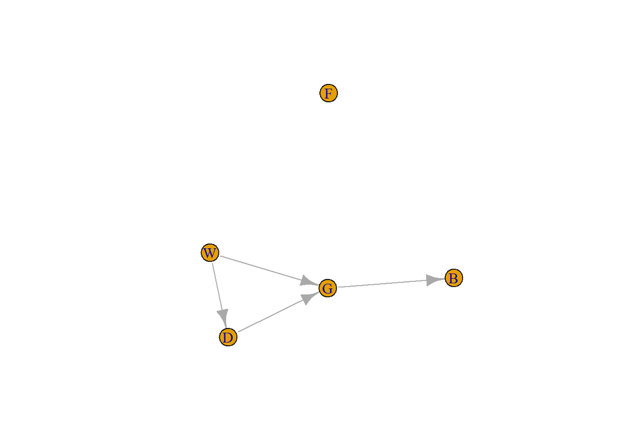

```r
# the graph showing object incompatibilities
gr <- make_empty_graph(directed = TRUE)
gr <- add.vertices(gr, 5, name = c('F', 'W', 'D', 'G', 'B'))
gr <- add.edges(gr, c('W','D', 'W','G', 'D', 'G', 'G', 'B'))
plot(gr)
```

```r
# create the search space
gss <- make_empty_graph(directed=FALSE)


boat.capacity <- 3
farmer.symbol <- 'F'

# create the initial state
state0 <- list(bank.l = c('F', 'W', 'W', 'D', 'G', 'B'), bank.r = c(), boat.pos = 1)
state0 <- make.state.name(state0)

# add the initial state as a node in the search space
gss <- add.vertices(gss, 1, name=state0$name)
V(gss)[1]$color <- 'red'

gss <- solve(gss, state0)
```

```
## solving BDFGWWb|
##   transition F W W
##   transition F W D
##   transition F W G
##   transition F W B
##   transition F W NA
##   transition F D G
## BWW|DFGb is valid
## solving BWW|DFGb
##   transition F D G
## BDFGWWb| is valid
##   transition F D NA
## BDFWWb|G is valid
## solving BDFWWb|G
##   transition W W F
## BD|FGWWb is valid
## solving BD|FGWWb
##   transition G W F
## BDFGWb|W is valid
## solving BDFGWb|W
##   transition B D F
##   transition B NA F
##   transition B G F
##   transition B W F
##   transition B F NA
##   transition D NA F
##   transition D G F
## BW|DFGWb is valid
## solving BW|DFGWb
##   transition W D F
## BDFWWb|G is valid
##   transition W G F
## BFGWWb|D is valid
## solving BFGWWb|D
##   transition B W F
##   transition B NA F
##   transition B G F
## WW|BDFGb is valid
## solving WW|BDFGb
##   transition D B F
```

[output cut: 187 more lines]

```
##   transition B F D
## WW|BDFGb is valid
##   transition B F NA
##   transition F D NA
## BWW|DFGb is valid
##   transition F NA NA
##   transition F G NA
## BFGWWb|D is valid
##   transition F NA NA
##   transition F D B
##   transition F D NA
##   transition F G B
##   transition F G NA
##   transition F B NA
##   transition F NA NA
```

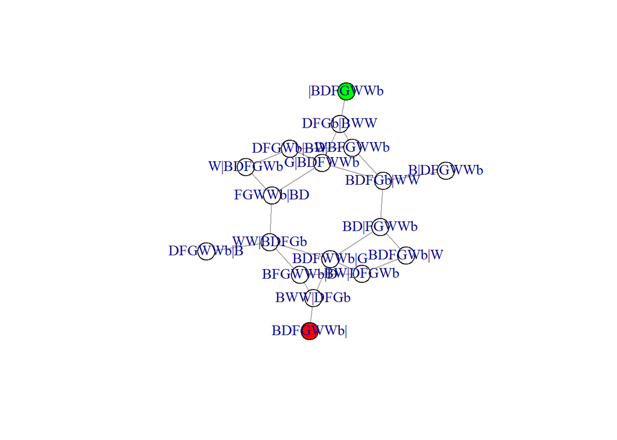

```r
gss <- simplify(gss, remove.loops = FALSE, remove.multiple = TRUE)

V(gss)[startsWith(V(gss)$name, '|')]$color <- 'green'
plot(gss)
```

Solving the puzzle by finding valid paths in the search space.

```r
paths <- get.all.shortest.paths(gss, 'BDFGWWb|', '|BDFGWWb')
print(paths)
```

```
## $res
## $res[[1]]
## + 8/18 vertices, named, from b439fcb:
## [1] BDFGWWb| BWW|DFGb BFGWWb|D WW|BDFGb FGWWb|BD G|BDFWWb DFGb|BWW |BDFGWWb
##
## $res[[2]]
## + 8/18 vertices, named, from b439fcb:
## [1] BDFGWWb| BWW|DFGb BDFWWb|G WW|BDFGb FGWWb|BD G|BDFWWb DFGb|BWW |BDFGWWb
##
## $res[[3]]
## + 8/18 vertices, named, from b439fcb:
## [1] BDFGWWb| BWW|DFGb BDFWWb|G BD|FGWWb BDFGb|WW G|BDFWWb DFGb|BWW |BDFGWWb
##
## $res[[4]]
## + 8/18 vertices, named, from b439fcb:
## [1] BDFGWWb| BWW|DFGb BDFWWb|G BD|FGWWb BDFGb|WW D|BFGWWb DFGb|BWW |BDFGWWb
##
##
## $nrgeo
##  [1] 1 1 1 1 3 2 1 2 2 2 3 1 1 1 6 2 4 4
```

```r
paths <- get.all.shortest.paths(gss, V(gss)[endsWith(V(gss)$name, '|')], V(gss)[startsWith(V(gss)$name, '|')])
print(paths)
```

```
## $res
## $res[[1]]
## + 8/18 vertices, named, from b439fcb:
## [1] BDFGWWb| BWW|DFGb BFGWWb|D WW|BDFGb FGWWb|BD G|BDFWWb DFGb|BWW |BDFGWWb
##
## $res[[2]]
## + 8/18 vertices, named, from b439fcb:
## [1] BDFGWWb| BWW|DFGb BDFWWb|G WW|BDFGb FGWWb|BD G|BDFWWb DFGb|BWW |BDFGWWb
##
## $res[[3]]
## + 8/18 vertices, named, from b439fcb:
## [1] BDFGWWb| BWW|DFGb BDFWWb|G BD|FGWWb BDFGb|WW G|BDFWWb DFGb|BWW |BDFGWWb
##
## $res[[4]]
## + 8/18 vertices, named, from b439fcb:
## [1] BDFGWWb| BWW|DFGb BDFWWb|G BD|FGWWb BDFGb|WW D|BFGWWb DFGb|BWW |BDFGWWb
##
##
## $nrgeo
##  [1] 1 1 1 1 3 2 1 2 2 2 3 1 1 1 6 2 4 4
```

**Missionaries and Cannibals**

For this problem, we need to consider counts of objects rather than incompatibilities between object types. Thus we will ovveride some of the functions in `solve_river_crossing_puzzles.R` that we have used out-of-the-box for the previous puzzles.

```r
# for this problem, we need to consider counts of objects rather than incompatibilities between object types; thus override this method
is.bank.valid <- function(gr, state, side)
{
     b <- state[[side]]
     t <- table(b)
     num.c <- ifelse(is.na(t['C']), 0, t['C'])
     num.m <- ifelse(is.na(t['M']), 0, t['M'])
     return(num.m >= num.c | num.m == 0)
}

# for this problem, the only rule is that the boat is not empty; thus override this method
is.transition.valid <- function(transition)
{
     return(min(is.na(transition)) == 0)
}
```

We create the search space illustrating all possible transitions (moves) that can be done.

```r
# the graph showing object incompatibilities; not used in this particular case - we will leave it empty
gr <- make_empty_graph(directed = TRUE)

# create the search space
gss <- make_empty_graph(directed = FALSE)


boat.capacity <- 2

# create the initial state
state0 <- list(bank.l = c('M', 'M', 'M', 'C', 'C', 'C'), bank.r = vector(), boat.pos = 1)
state0 <- make.state.name(state0)

# add the initial state as a node in the search space
gss <- add.vertices(gss, 1, name=state0$name)
V(gss)[1]$color <- 'red'

gss <- solve(gss, state0)
```

```
## solving CCCMMMb|
##   transition M M
##   transition M C
## CCMM|CMb is valid
## solving CCMM|CMb
##   transition M C
## CCCMMMb| is valid
##   transition M NA
## CCMMMb|C is valid
## solving CCMMMb|C
##   transition M M
##   transition M C
##   transition M NA
## CCMM|CMb is valid
##   transition C C
## MMM|CCCb is valid
## solving MMM|CCCb
##   transition C C
## CCMMMb|C is valid
##   transition C NA
## CMMMb|CC is valid
## solving CMMMb|CC
##   transition M M
## CM|CCMMb is valid
## solving CM|CCMMb
##   transition C C
##   transition C M
## CCMMb|CM is valid
## solving CCMMb|CM
##   transition M C
## CM|CCMMb is valid
##   transition M NA
##   transition M M
## CC|CMMMb is valid
## solving CC|CMMMb
##   transition C M
##   transition C NA
## CCCb|MMM is valid
## solving CCCb|MMM
##   transition C C
```

[output cut: 66 more lines]

```
## CMMM|CCb is valid
## solving CMMM|CCb
##   transition C C
## CCCMMMb| is valid
##   transition C NA
## CCMMMb|C is valid
##   transition C NA
##   transition M NA
##   transition C C
## CMMM|CCb is valid
##   transition C NA
## CCMMM|Cb is valid
## solving CCMMM|Cb
##   transition C NA
## CCCMMMb| is valid
```

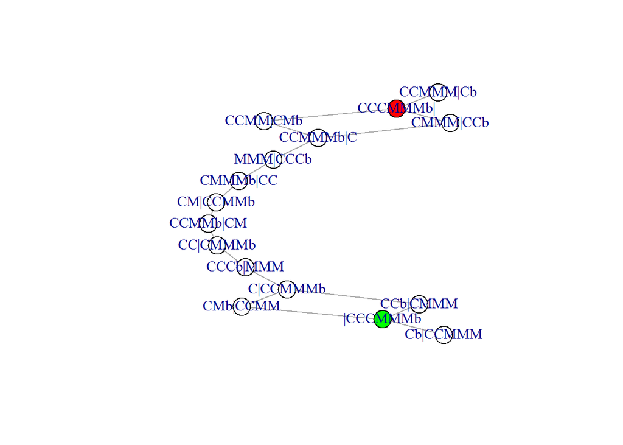

```r
gss <- simplify(gss, remove.loops = FALSE, remove.multiple = TRUE)

V(gss)[startsWith(V(gss)$name, '|')]$color <- 'green'
plot(gss)
```

Solving the puzzle by finding valid paths in the search space.

```r
paths <- get.all.shortest.paths(gss, 'CCCMMMb|', '|CCCMMMb')
print(paths)
```

```
## $res
## $res[[1]]
## + 12/16 vertices, named, from b47f6ae:
##  [1] CCCMMMb| CCMM|CMb CCMMMb|C MMM|CCCb CMMMb|CC CM|CCMMb CCMMb|CM
##  [8] CC|CMMMb CCCb|MMM C|CCMMMb CCb|CMMM |CCCMMMb
##
## $res[[2]]
## + 12/16 vertices, named, from b47f6ae:
##  [1] CCCMMMb| CMMM|CCb CCMMMb|C MMM|CCCb CMMMb|CC CM|CCMMb CCMMb|CM
##  [8] CC|CMMMb CCCb|MMM C|CCMMMb CCb|CMMM |CCCMMMb
##
## $res[[3]]
## + 12/16 vertices, named, from b47f6ae:
##  [1] CCCMMMb| CCMM|CMb CCMMMb|C MMM|CCCb CMMMb|CC CM|CCMMb CCMMb|CM
##  [8] CC|CMMMb CCCb|MMM C|CCMMMb CMb|CCMM |CCCMMMb
##
## $res[[4]]
## + 12/16 vertices, named, from b47f6ae:
##  [1] CCCMMMb| CMMM|CCb CCMMMb|C MMM|CCCb CMMMb|CC CM|CCMMb CCMMb|CM
##  [8] CC|CMMMb CCCb|MMM C|CCMMMb CMb|CCMM |CCCMMMb
##
##
## $nrgeo
##  [1] 1 1 2 2 2 2 2 2 2 2 2 4 2 0 1 1
```

**Japanese Family River Crossing Puzzle**

Again, for this puzzle we need to override some of the standard methods in file `solve_river_crossing_puzzles.R`.

```r
# for this problem, we need to consider complex incompatibilities between object types; thus override this method
is.bank.valid <- function(gr, state, side)
{
    b <- state[[side]]
    if (! is.element('M',b) & length(b) > 1 & is.element('F',b) & is.element('D',b))     { return (FALSE) }
    if (! is.element('F',b) & length(b) > 1 & is.element('M',b) & is.element('S',b))     { return (FALSE) }
    if (! is.element('P',b) & length(b) > 1 & is.element('T',b) & (is.element('F',b) | is.element('M',b) | is.element('S',b) | is.element('D',b)))     { return (FALSE) }

    return(TRUE)
}

# for this problem, multiple persons can operate the boat; thus override this method
is.transition.valid <- function(transition)
{
     return(is.element('M', transition) | is.element('F', transition) | is.element('P', transition))
}
```

We create the search space illustrating all possible transitions (moves) that can be done.

```r
# the graph showing object incompatibilities; not used in this particular case
gr <- make_empty_graph(directed = TRUE)

# create the search space
gss <- make_empty_graph(directed = FALSE)


boat.capacity <- 2

# create the initial state
state0 <- list(bank.l = c('F', 'M', 'P', 'T', 'D', 'D', 'S', 'S'), bank.r = vector(), boat.pos = 1)
state0 <- make.state.name(state0)

# add the initial state as a node in the search space
gss <- add.vertices(gss, 1, name=state0$name)
V(gss)[1]$color <- 'red'

gss <- solve(gss, state0)
```

```
## solving DDFMPSSTb|
##   transition F M
## DDPSST|FMb is valid
## solving DDPSST|FMb
##   transition F M
## DDFMPSSTb| is valid
##   transition F NA
##   transition M NA
##   transition F P
##   transition F T
##   transition F D
##   transition F S
##   transition F NA
##   transition M P
##   transition M T
##   transition M D
##   transition M S
##   transition M NA
##   transition P T
## DDFMSS|PTb is valid
## solving DDFMSS|PTb
##   transition P T
## DDFMPSSTb| is valid
##   transition P NA
## DDFMPSSb|T is valid
## solving DDFMPSSb|T
##   transition F M
##   transition F D
##   transition F S
##   transition F P
##   transition F NA
##   transition M D
##   transition M S
##   transition M P
##   transition M NA
##   transition D P
## DFMSS|DPTb is valid
## solving DFMSS|DPTb
##   transition T P
## DFMPSSTb|D is valid
```

[output cut: 526 more lines]

```
##   transition S P
##   transition NA P
##   transition T P
## DFMSS|DPTb is valid
##   transition P NA
##   transition D P
## DDFMPSSb|T is valid
##   transition P NA
##   transition S P
## DDFMS|PSTb is valid
##   transition P NA
## DDFMSS|PTb is valid
##   transition P D
##   transition P S
##   transition P NA
```

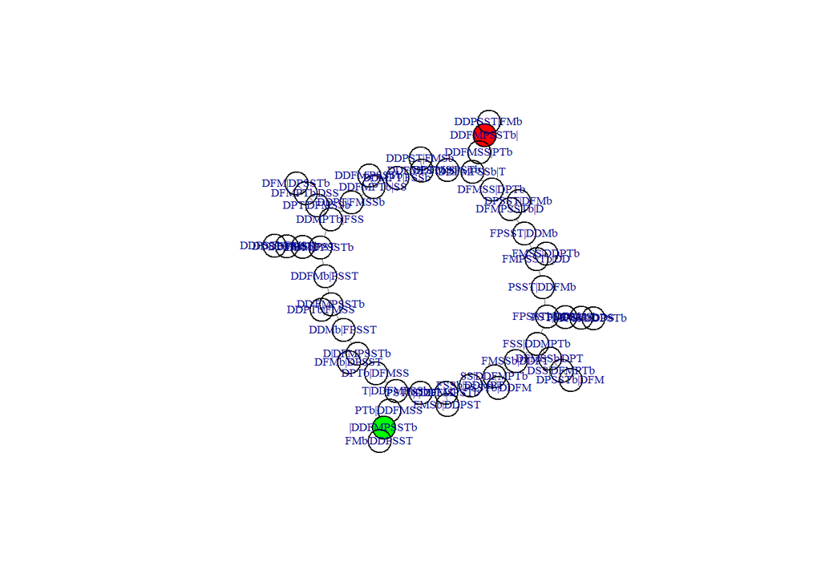

```r
gss <- simplify(gss, remove.loops = FALSE, remove.multiple = TRUE)

V(gss)[startsWith(V(gss)$name, '|')]$color <- 'green'
plot(gss, layout=layout.fruchterman.reingold(gss, niter=10000), vertex.label.cex=0.6)
```

Solving the puzzle by finding valid paths in the search space.

```r
paths <- get.all.shortest.paths(gss, 'DDFMPSSTb|', '|DDFMPSSTb')
```